# iodyne_data

```python
import pandas as pd
import numpy as np
import matplotlib.pyplot as plt
```

```python
# This csv is all json files under "DCSM_GENERAL_METADATA"
df = pd.read_csv('ssd_data.csv')
```

```python
print(f"Shape: {df.shape}")
print(f"Columns: {df.columns.tolist()}")
print(f"\nData types:")
print(df.dtypes)
print(f"\nNull values:")
print(df.isnull().sum())
```

```
Shape: (5146, 33)
Columns: ['timestamp', 'device_id', 'ssd_name', 'log_type', 'file_source', 'sm_spare', 'sm_crit', 'sm_mdie', 'sm_used', 'sm_pc', 'sm_poh', 'sm_wctt', 'sm_cctt', 'sm_reads', 'sm_writes', 'sm_rbytes', 'sm_wbytes', 'state', 'slot', 'sn', 'namespace_id', 'namespace_name', 'read_ops', 'read_bytes', 'read…

Data types:
timestamp          object
device_id          object
ssd_name           object
log_type           object
file_source        object
sm_spare          float64
sm_crit           float64
sm_mdie           float64
sm_used           float64
sm_pc             float64
sm_poh            float64
sm_wctt           float64
sm_cctt           float64
sm_reads          float64
sm_writes         float64
sm_rbytes         float64
sm_wbytes         float64
state              object
slot              float64
sn                 object
namespace_id       object
namespace_name     object
read_ops          float64
read_bytes        float64
read_misalign     float64
write_ops         float64
write_bytes       float64
write_misalign    float64
trim_ops          float64
trim_bytes        float64
trim_misalign     float64
size              float64
nsid              float64
dtype: object

Null values:
```

[output cut: 19 more lines]

```
sn                 790
namespace_id      4356
namespace_name    4356
read_ops          4356
read_bytes        4356
read_misalign     4356
write_ops         4356
write_bytes       4356
write_misalign    4356
trim_ops          4356
trim_bytes        4356
trim_misalign     4356
size              4356
nsid              4356
dtype: int64
```

# SMART METRICS

## These metrics indicate the physical health of hardware and wear patterns.

- sm_spare: Spare Blocks(wear level reserve)
- sm_crit: Critical warnings or error flags
- sm_mdie: Media and Data Integrity Errors
- sm_used: Percentage of drive lifetime used (wear indicator)
- sm_pc: Power cycles (how many times drive was powered on/off)
- sm_poh: Power-On Hours (total time drive has been running)
- sm_wctt: Write Command Timeout Threshold
- sm_cctt: Controller Command Timeout Threshold
- sm_reads: Total read commands issued to the drive
- sm_writes: Total write commands issued to the drive
- sm_rbytes: Total bytes read from the drive
- sm_wbytes: Total bytes written to the drive

# NAMESPACE

## This will tell me which applications/workloads are causing performance patterns

- read_ops: Number of read operations on this namespace
- read_bytes: Total bytes read from this namespace
- read_misalign: Read operations that weren't aligned to storage boundaries
- write_ops: Number of write operations on this namespace
- write_bytes: Total bytes written to this namespace
- write_misalign: Write operations that weren't aligned

```python
df.describe()
```

|  | sm_spare | sm_crit | sm_mdie | sm_used | sm_pc | sm_poh | sm_wctt | sm_cctt | sm_reads | sm_writes | ... | read_bytes | read_misalign | write_ops | write_bytes | write_misalign | trim_ops | trim_bytes | trim_misalign | size | nsid |
| --- | --- | --- | --- | --- | --- | --- | --- | --- | --- | --- | --- | --- | --- | --- | --- | --- | --- | --- | --- | --- | --- |
| count | 4356.0 | 4356.0 | 4356.0 | 4356.000000 | 4356.000000 | 4356.000000 | 4356.0 | 4356.0 | 4.356000e+03 | 4.356000e+03 | ... | 7.900000e+02 | 7.900000e+02 | 7.900000e+02 | 7.900000e+02 | 7.900000e+02 | 7.900000e+02 | 7.900000e+02 | 7.900000e+02 | 7.900000e+02 | 790.000000 |
| mean | 100.0 | 0.0 | 0.0 | 14.344582 | 535.150826 | 11148.606520 | 0.0 | 0.0 | 6.469103e+08 | 8.073531e+08 | ... | 2.501359e+12 | 2.100057e+12 | 2.281574e+07 | 2.660176e+12 | 4.840721e+11 | 1.977287e+07 | 8.229363e+12 | 6.040490e+10 | 1.831650e+12 | 2.682278 |
| std | 0.0 | 0.0 | 0.0 | 0.475286 | 14.354187 | 4008.458295 | 0.0 | 0.0 | 5.752810e+07 | 5.039149e+07 | ... | 4.462965e+12 | 3.525753e+12 | 3.086696e+07 | 3.719850e+12 | 7.287032e+11 | 2.355058e+07 | 1.148682e+13 | 1.033559e+11 | 1.375052e+12 | 1.434348 |
| min | 100.0 | 0.0 | 0.0 | 14.000000 | 475.000000 | 1227.000000 | 0.0 | 0.0 | 5.870085e+08 | 7.489795e+08 | ... | 4.915200e+04 | 2.129920e+05 | 0.000000e+00 | 0.000000e+00 | 0.000000e+00 | 0.000000e+00 | 0.000000e+00 | 0.000000e+00 | 1.000243e+07 | 1.000000 |
| 25% | 100.0 | 0.0 | 0.0 | 14.000000 | 530.000000 | 9818.000000 | 0.0 | 0.0 | 6.072302e+08 | 7.730106e+08 | ... | 8.832305e+10 | 2.016395e+09 | 1.224994e+06 | 1.398186e+11 | 6.136996e+08 | 2.600000e+01 | 1.006633e+08 | 2.826240e+05 | 1.000000e+12 | 1.000000 |
| 50% | 100.0 | 0.0 | 0.0 | 14.000000 | 532.000000 | 9828.000000 | 0.0 | 0.0 | 6.077169e+08 | 7.742686e+08 | ... | 8.408154e+11 | 1.452653e+11 | 4.529126e+06 | 8.416932e+11 | 4.085634e+10 | 8.914574e+06 | 3.026337e+12 | 1.100233e+09 | 1.865672e+12 | 2.000000 |
| 75% | 100.0 | 0.0 | 0.0 | 15.000000 | 548.000000 | 12546.000000 | 0.0 | 0.0 | 7.157381e+08 | 8.671071e+08 | ... | 1.385482e+12 | 2.375372e+12 | 5.003691e+07 | 3.800446e+12 | 9.343550e+11 | 3.522351e+07 | 8.517168e+12 | 2.364527e+10 | 2.000000e+12 | 4.000000 |
| max | 100.0 | 0.0 | 0.0 | 15.000000 | 558.000000 | 19770.000000 | 0.0 | 0.0 | 7.518917e+08 | 8.968029e+08 | ... | 1.340102e+13 | 1.009032e+13 | 1.219368e+08 | 1.114698e+13 | 3.153008e+12 | 7.518226e+07 | 3.694241e+13 | 3.862000e+11 | 4.000000e+12 | 8.000000 |

8 rows × 24 columns

## Here we are separating the health records and namespace.

#### Insights from data 4,356 health records across the 3 distinct log types.

#### I decided to separate the name space from SSD hardware level layer while the namespace are partitions. Seems to have equal distribution between PERIODIC and FAULT logs. Periodic providing a good baseline for health monitoring

```python
df['timestamp'] = pd.to_datetime(df['timestamp'])

ssd_df = df[df['ssd_name'].notna()].copy()
ns_df = df[df['namespace_id'].notna()].copy()

print(f"SSD Health records: {len(ssd_df)}")
print(f"Namespace records: {len(ns_df)}")
print(f"SSD log types: {ssd_df['log_type'].value_counts()}")
```

```
SSD Health records: 4356
Namespace records: 790
SSD log types: log_type
FAULT       2016
PERIODIC    1980
HEALTH       360
Name: count, dtype: int64
```

```python
# Check temporal coverage
print(f"Time range: {df['timestamp'].min()} to {df['timestamp'].max()}")
print(f"Unique timestamps: {df['timestamp'].nunique()}")
print(f"Days covered: {(df['timestamp'].max() - df['timestamp'].min()).days}")

# Look for time series patterns
ssd_time_coverage = ssd_df.groupby('ssd_name')['timestamp'].agg(['count', 'nunique', 'min', 'max'])
print("SSD Time Coverage Summary:")
print(ssd_time_coverage.head())
```

```
Time range: 2022-04-15 19:35:32.387000+00:00 to 2025-05-27 21:52:37.772000+00:00
Unique timestamps: 562
Days covered: 1138
SSD Time Coverage Summary:
          count  nunique                              min  \
ssd_name
SSD1        363      363 2022-05-06 18:53:10.981000+00:00
SSD10       363      363 2022-05-06 18:53:10.981000+00:00
SSD11       363      363 2022-05-06 18:53:10.981000+00:00
SSD12       363      363 2022-05-06 18:53:10.981000+00:00
SSD2        363      363 2022-05-06 18:53:10.981000+00:00

                                      max
ssd_name
SSD1     2025-05-27 21:52:36.703000+00:00
SSD10    2025-05-27 21:52:36.703000+00:00
SSD11    2025-05-27 21:52:36.703000+00:00
SSD12    2025-05-27 21:52:36.703000+00:00
SSD2     2025-05-27 21:52:36.703000+00:00
```

#### Exploring the SMART metrics here. For the flag conditions the decision was based on research on what is normally used to flag degradation indicators. Spare block depletion, critical warnings, errors, spare blocks(this indicates wear)

```python
# Look for degradation signals
ssd_health_summary = ssd_df.groupby('ssd_name').agg({
    'sm_spare': ['min', 'max', 'std'],
    'sm_crit': ['sum', 'max'],
    'sm_mdie': ['sum', 'max'],
    'sm_used': ['min', 'max'],
    'sm_poh': ['min', 'max'],
    'sm_pc': ['min', 'max'],
    'timestamp': 'count'
})

# Flatten column names
ssd_health_summary.columns = ['_'.join(col).strip() for col in ssd_health_summary.columns]

# Flag potential issues
degradation_flags = ssd_health_summary[
    (ssd_health_summary['sm_spare_min'] < 100) |
    (ssd_health_summary['sm_crit_sum'] > 0) |
    (ssd_health_summary['sm_mdie_sum'] > 0) |
    (ssd_health_summary['sm_spare_std'] > 0)  # Any variance in spare blocks = degradation
]

print(f"SSDs showing potential degradation: {len(degradation_flags)}")
```

```
SSDs showing potential degradation: 0
```

```python
# Critical: Compare health metrics between fault and normal operation
fault_analysis = ssd_df.groupby(['ssd_name', 'log_type']).agg({
    'sm_spare': 'mean',
    'sm_crit': 'sum',
    'sm_mdie': 'sum',
    'sm_used': 'mean',
    'timestamp': 'count'
}).reset_index()

# Pivot to compare FAULT vs PERIODIC for same SSDs
fault_pivot = fault_analysis.pivot(index='ssd_name', columns='log_type', values='sm_spare')
print("Spare Block Comparison (FAULT vs PERIODIC):")
print(fault_pivot.head())

# Look for SSDs with both FAULT and PERIODIC data
both_types = fault_pivot.dropna()
if len(both_types) > 0:
    print(f"\nSSDs with both FAULT and PERIODIC data: {len(both_types)}")
```

```
Spare Block Comparison (FAULT vs PERIODIC):
log_type  FAULT  HEALTH  PERIODIC
ssd_name
SSD1      100.0   100.0     100.0
SSD10     100.0   100.0     100.0
SSD11     100.0   100.0     100.0
SSD12     100.0   100.0     100.0
SSD2      100.0   100.0     100.0

SSDs with both FAULT and PERIODIC data: 12
```

```python
# Check namespace utilization patterns
if len(ns_df) > 0:
    ns_summary = ns_df.groupby('namespace_name').agg({
        'read_ops': 'sum',
        'write_ops': 'sum',
        'read_misalign': 'sum',
        'write_misalign': 'sum',
        'size': 'first'
    })

    # Calculate misalignment rates
    ns_summary['read_misalign_rate'] = ns_summary['read_misalign'] / ns_summary['read_ops']
    ns_summary['write_misalign_rate'] = ns_summary['write_misalign'] / ns_summary['write_ops']

    print("High misalignment workloads (stress indicators):")
    print(ns_summary[ns_summary['write_misalign_rate'] > 0.1])
```

```
High misalignment workloads (stress indicators):
                           read_ops     write_ops  read_misalign  \
namespace_name
DWW Mac Backup         4.068911e+10  6.991795e+09   1.169011e+15
Danes Test             4.816060e+06  4.767092e+06   1.385319e+11
Hedge Test 2           4.531870e+05  5.887620e+05   1.326564e+10
JJWW Time Machine      7.501665e+08  8.443150e+08   2.143746e+13
NXNW XFER              2.993058e+07  1.461314e+07   8.566415e+11
Photo & Video Archive  6.061130e+08  6.604071e+08   1.889822e+13
Photos                 3.040303e+06  9.398088e+06   8.772102e+10
R0                     1.298600e+04  5.079000e+03   3.727688e+08
R6                     9.003880e+05  6.253310e+05   2.943836e+10
Test                   1.450000e+03  1.990000e+02   3.848602e+07
Time Machine           1.553155e+10  9.261394e+09   4.448995e+14
Virtual Machines       4.003029e+07  2.203678e+07   1.149512e+12
Windows                1.450500e+04  4.333000e+03   2.810675e+08
Windows PD Test        2.610146e+08  1.323065e+08   2.463913e+11
Windows Test           9.776200e+04  1.418260e+05   2.066162e+09
exfat1                 3.840000e+03  5.695000e+03   9.849651e+07
full                   6.233680e+05  5.196720e+05   1.197665e+10
iPad Test              1.824000e+03  1.073000e+03   5.195366e+07
jjww Personal          7.462267e+07  8.126329e+07   2.262555e+12

                       write_misalign          size  read_misalign_rate  \
namespace_name
DWW Mac Backup           1.152908e+14  3.000000e+11        28730.318339
Danes Test               1.371625e+11  4.000000e+12        28764.572189
Hedge Test 2             1.736799e+10  1.000000e+12        29271.884180
JJWW Time Machine        2.198932e+13  4.000000e+12        28576.936025
NXNW XFER                4.186520e+11  3.150635e+12        28620.944142
Photo & Video Archive    5.958734e+12  2.000000e+12        31179.370223
Photos                   2.697353e+11  2.000000e+12        28852.723377
R0                       1.459200e+08  5.000000e+11        28705.434160
R6                       1.383371e+09  5.000000e+11        32695.190855
Test                     4.067328e+06  1.731344e+12        26542.080000
Time Machine             2.368207e+14  4.000000e+12        28644.877217
Virtual Machines         6.704325e+11  1.000000e+12        28716.044013
Windows                  1.368801e+08  1.000000e+12        19377.285074
Windows PD Test          7.052968e+10  1.000000e+12          943.975051
Windows Test             4.395749e+09  5.000000e+11        21134.609194
```

[output cut: 11 more lines]

```
NXNW XFER                     28649.019390
Photo & Video Archive          9022.819243
Photos                        28701.077928
R0                            28730.064973
R6                             2212.221611
Test                          20438.834171
Time Machine                  25570.742064
Virtual Machines              30423.333753
Windows                       31590.151858
Windows PD Test                 533.077805
Windows Test                  30993.960036
exfat1                        22024.181212
full                          26360.129928
iPad Test                     29053.733458
jjww Personal                  9273.299996
```

```python
# Match workload stress to SSD health
# Get device-level workload stress
workload_stress = ns_df.groupby('device_id').agg({
    'write_misalign': 'sum',
    'write_ops': 'sum',
    'read_misalign': 'sum',
    'read_ops': 'sum'
})

workload_stress['write_misalign_rate'] = workload_stress['write_misalign'] / workload_stress['write_ops']
workload_stress['read_misalign_rate'] = workload_stress['read_misalign'] / workload_stress['read_ops']

# Merge with SSD health data
ssd_latest = ssd_df.loc[ssd_df.groupby('ssd_name')['timestamp'].idxmax()]
workload_correlation = ssd_latest.merge(workload_stress, on='device_id', how='left')

print("Correlation between workload stress and SSD health:")
print(workload_correlation[['ssd_name', 'sm_spare', 'sm_crit', 'sm_mdie', 'write_misalign_rate']].head())
```

```
Correlation between workload stress and SSD health:
  ssd_name  sm_spare  sm_crit  sm_mdie  write_misalign_rate
0     SSD1     100.0      0.0      0.0         21216.585111
1    SSD10     100.0      0.0      0.0         21216.585111
2    SSD11     100.0      0.0      0.0         21216.585111
3    SSD12     100.0      0.0      0.0         21216.585111
4     SSD2     100.0      0.0      0.0         21216.585111
```

#### Here we compare SMART metrics between the fault events and normal periodic monitoring, to identify correlation with failures.

```python
# This is THE most important analysis right now
print("=== FAULT vs PERIODIC COMPARISON ===")

fault_data = ssd_df[ssd_df['log_type'] == 'FAULT']
periodic_data = ssd_df[ssd_df['log_type'] == 'PERIODIC']

comparison_metrics = ['sm_spare', 'sm_crit', 'sm_mdie', 'sm_wctt', 'sm_cctt', 'sm_used', 'sm_pc', 'sm_poh']

for metric in comparison_metrics:
    fault_vals = fault_data[metric].describe()
    periodic_vals = periodic_data[metric].describe()

    print(f"\n{metric.upper()}:")
    print(f"FAULT    - mean: {fault_vals['mean']:.2f}, std: {fault_vals['std']:.2f}, range: {fault_vals['min']:.1f}-{fault_vals['max']:.1f}")
    print(f"PERIODIC - mean: {periodic_vals['mean']:.2f}, std: {periodic_vals['std']:.2f}, range: {periodic_vals['min']:.1f}-{periodic_vals['max']:.1f}")

    # Check if there's ANY difference
    if fault_vals['mean'] != periodic_vals['mean'] or fault_vals['std'] != periodic_vals['std']:
        print(f"*** DIFFERENCE DETECTED in {metric} ***")
```

```
=== FAULT vs PERIODIC COMPARISON ===

SM_SPARE:
FAULT    - mean: 100.00, std: 0.00, range: 100.0-100.0
PERIODIC - mean: 100.00, std: 0.00, range: 100.0-100.0

SM_CRIT:
FAULT    - mean: 0.00, std: 0.00, range: 0.0-0.0
PERIODIC - mean: 0.00, std: 0.00, range: 0.0-0.0

SM_MDIE:
FAULT    - mean: 0.00, std: 0.00, range: 0.0-0.0
PERIODIC - mean: 0.00, std: 0.00, range: 0.0-0.0

SM_WCTT:
FAULT    - mean: 0.00, std: 0.00, range: 0.0-0.0
PERIODIC - mean: 0.00, std: 0.00, range: 0.0-0.0

SM_CCTT:
FAULT    - mean: 0.00, std: 0.00, range: 0.0-0.0
PERIODIC - mean: 0.00, std: 0.00, range: 0.0-0.0

SM_USED:
FAULT    - mean: 14.04, std: 0.19, range: 14.0-15.0
PERIODIC - mean: 14.66, std: 0.48, range: 14.0-15.0
*** DIFFERENCE DETECTED in sm_used ***

SM_PC:
FAULT    - mean: 530.44, std: 7.17, range: 481.0-557.0
PERIODIC - mean: 543.21, std: 10.78, range: 515.0-558.0
*** DIFFERENCE DETECTED in sm_pc ***

SM_POH:
FAULT    - mean: 9721.94, std: 1764.15, range: 1274.0-19765.0
PERIODIC - mean: 13301.92, std: 4039.13, range: 4368.0-19770.0
*** DIFFERENCE DETECTED in sm_poh ***
```

```python
# Critical: Are faults clustered in time?
fault_timeline = ssd_df[ssd_df['log_type'] == 'FAULT']['timestamp'].value_counts().sort_index()
periodic_timeline = ssd_df[ssd_df['log_type'] == 'PERIODIC']['timestamp'].value_counts().sort_index()

print("Fault Pattern Analysis:")
print(f"Unique fault timestamps: {len(fault_timeline)}")
print(f"Unique periodic timestamps: {len(periodic_timeline)}")

# Check for temporal clustering
daily_faults = ssd_df[ssd_df['log_type'] == 'FAULT']['timestamp'].dt.date.value_counts()
print(f"Days with faults: {len(daily_faults)}")
print(f"Max faults per day: {daily_faults.max()}")
print(f"Days with ALL 12 SSDs faulting: {(daily_faults >= 12).sum()}")

# Show recent pattern
print("\nRecent fault activity:")
print(daily_faults.tail(10))
```

```
Fault Pattern Analysis:
Unique fault timestamps: 168
Unique periodic timestamps: 165
Days with faults: 11
Max faults per day: 1788
Days with ALL 12 SSDs faulting: 11

Recent fault activity:
timestamp
2024-03-29    72
2023-02-13    48
2022-05-12    24
2022-07-28    12
2024-06-05    12
2024-06-12    12
2024-07-23    12
2024-11-12    12
2025-03-17    12
2025-05-27    12
Name: count, dtype: int64
```

```python
# Identify mass fault events
mass_fault_days = ssd_df[ssd_df['log_type'] == 'FAULT']['timestamp'].dt.date.value_counts()
mass_events = mass_fault_days[mass_fault_days >= 12]  # All SSDs faulted

print("Mass Fault Events (All SSDs):")
for date, count in mass_events.items():
    print(f"{date}: {count} faults")

    # What was different on these days?
    day_data = ssd_df[ssd_df['timestamp'].dt.date == date]
    print(f"  Avg completion times: {day_data['sm_wctt'].mean():.2f}")
    print(f"  Workload pattern: {day_data['log_type'].value_counts().to_dict()}")
```

```
Mass Fault Events (All SSDs):
2024-03-30: 1788 faults
  Avg completion times: 0.00
  Workload pattern: {'FAULT': 1788, 'PERIODIC': 12}
2024-03-29: 72 faults
  Avg completion times: 0.00
  Workload pattern: {'FAULT': 72, 'HEALTH': 12, 'PERIODIC': 12}
2023-02-13: 48 faults
  Avg completion times: 0.00
  Workload pattern: {'FAULT': 48, 'PERIODIC': 12}
2022-05-12: 24 faults
  Avg completion times: 0.00
  Workload pattern: {'FAULT': 24, 'HEALTH': 12}
2022-07-28: 12 faults
  Avg completion times: 0.00
  Workload pattern: {'FAULT': 12, 'HEALTH': 12}
2024-06-05: 12 faults
  Avg completion times: 0.00
  Workload pattern: {'PERIODIC': 12, 'FAULT': 12, 'HEALTH': 12}
2024-06-12: 12 faults
  Avg completion times: 0.00
  Workload pattern: {'PERIODIC': 24, 'FAULT': 12}
2024-07-23: 12 faults
  Avg completion times: 0.00
  Workload pattern: {'HEALTH': 24, 'FAULT': 12, 'PERIODIC': 12}
2024-11-12: 12 faults
  Avg completion times: 0.00
  Workload pattern: {'FAULT': 12, 'PERIODIC': 12}
2025-03-17: 12 faults
  Avg completion times: 0.00
  Workload pattern: {'FAULT': 12}
2025-05-27: 12 faults
  Avg completion times: 0.00
  Workload pattern: {'PERIODIC': 24, 'FAULT': 12}
```

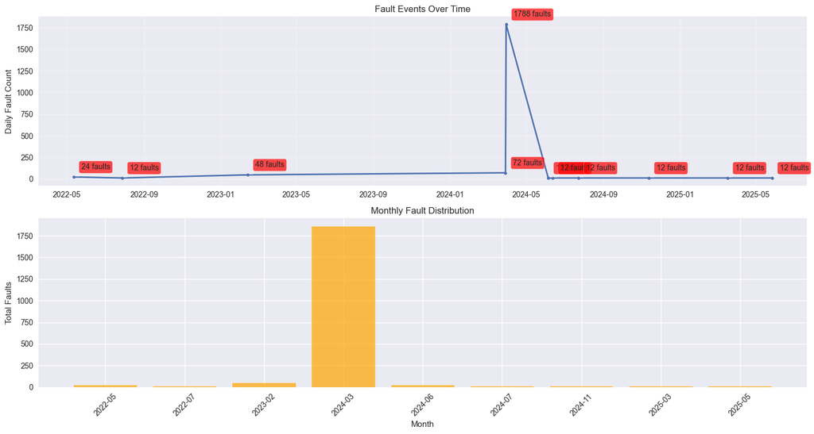

```python
# Fault events over time
fig, axes = plt.subplots(2, 1, figsize=(15, 8))

# Daily fault count timeline
daily_faults = ssd_df[ssd_df['log_type'] == 'FAULT'].groupby(
    ssd_df['timestamp'].dt.date
).size()

axes[0].plot(daily_faults.index, daily_faults.values, marker='o', linewidth=2, markersize=4)
axes[0].set_title('Fault Events Over Time')
axes[0].set_ylabel('Daily Fault Count')
axes[0].grid(True, alpha=0.3)

# Mark mass fault events
mass_events = daily_faults[daily_faults >= 12]
for date, count in mass_events.items():
    axes[0].annotate(f'{count} faults', xy=(date, count),
                     xytext=(10, 10), textcoords='offset points',
                     bbox=dict(boxstyle='round,pad=0.3', facecolor='red', alpha=0.7),
                     arrowprops=dict(arrowstyle='->', connectionstyle='arc3,rad=0'))

# Monthly fault pattern
monthly_faults = ssd_df[ssd_df['log_type'] == 'FAULT'].groupby(
    ssd_df['timestamp'].dt.to_period('M')
).size()

axes[1].bar(range(len(monthly_faults)), monthly_faults.values, alpha=0.7, color='orange')
axes[1].set_title('Monthly Fault Distribution')
axes[1].set_xlabel('Month')
axes[1].set_ylabel('Total Faults')
axes[1].set_xticks(range(len(monthly_faults)))
axes[1].set_xticklabels([str(p) for p in monthly_faults.index], rotation=45)

plt.tight_layout()
plt.show()
```

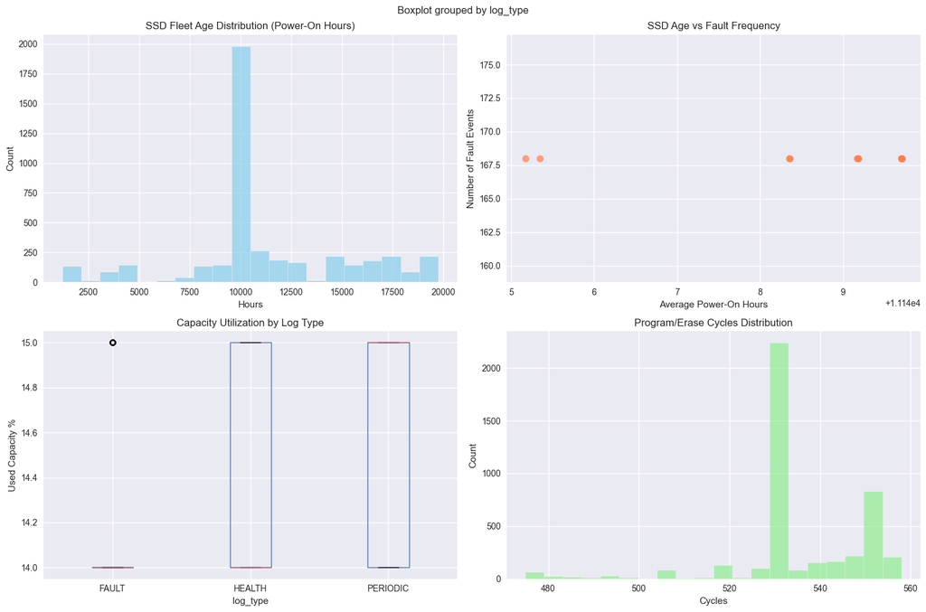

```python
# Set up the plotting style
plt.style.use('seaborn-v0_8')
fig, axes = plt.subplots(2, 2, figsize=(15, 10))

# Age distribution across fleet
ssd_df['sm_poh'].hist(bins=20, ax=axes[0,0], alpha=0.7, color='skyblue')
axes[0,0].set_title('SSD Fleet Age Distribution (Power-On Hours)')
axes[0,0].set_xlabel('Hours')
axes[0,0].set_ylabel('Count')

# Age vs Fault frequency
age_fault_data = ssd_df.groupby('ssd_name').agg({
    'sm_poh': 'mean',
    'log_type': lambda x: (x == 'FAULT').sum()
}).rename(columns={'log_type': 'fault_count'})

axes[0,1].scatter(age_fault_data['sm_poh'], age_fault_data['fault_count'],
                  alpha=0.7, s=60, color='coral')
axes[0,1].set_title('SSD Age vs Fault Frequency')
axes[0,1].set_xlabel('Average Power-On Hours')
axes[0,1].set_ylabel('Number of Fault Events')

# Utilization patterns by log type
ssd_df.boxplot(column='sm_used', by='log_type', ax=axes[1,0])
axes[1,0].set_title('Capacity Utilization by Log Type')
axes[1,0].set_ylabel('Used Capacity %')

# Program cycles distribution
ssd_df['sm_pc'].hist(bins=20, ax=axes[1,1], alpha=0.7, color='lightgreen')
axes[1,1].set_title('Program/Erase Cycles Distribution')
axes[1,1].set_xlabel('Cycles')
axes[1,1].set_ylabel('Count')

plt.tight_layout()
plt.show()
```

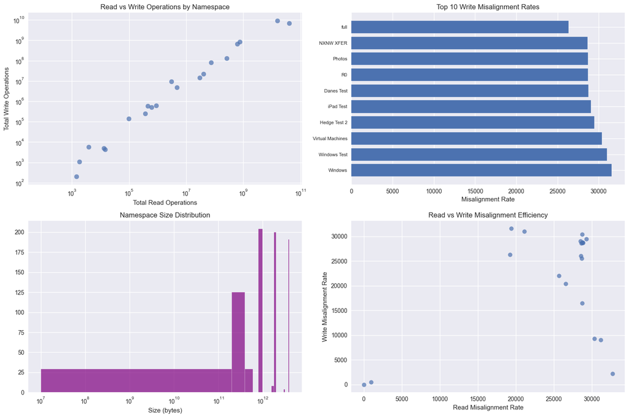

```python
# Namespace workload patterns
if len(ns_df) > 0:
    fig, axes = plt.subplots(2, 2, figsize=(15, 10))

    # Read vs Write operations
    ns_summary = ns_df.groupby('namespace_name').agg({
        'read_ops': 'sum',
        'write_ops': 'sum',
        'read_misalign': 'sum',
        'write_misalign': 'sum'
    })

    axes[0,0].scatter(ns_summary['read_ops'], ns_summary['write_ops'],
                      alpha=0.7, s=60)
    axes[0,0].set_title('Read vs Write Operations by Namespace')
    axes[0,0].set_xlabel('Total Read Operations')
    axes[0,0].set_ylabel('Total Write Operations')
    axes[0,0].set_xscale('log')
    axes[0,0].set_yscale('log')

    # Misalignment rates
    ns_summary['read_misalign_rate'] = ns_summary['read_misalign'] / ns_summary['read_ops']
    ns_summary['write_misalign_rate'] = ns_summary['write_misalign'] / ns_summary['write_ops']

    # Top 10 highest misalignment workloads
    top_misalign = ns_summary.nlargest(10, 'write_misalign_rate')

    axes[0,1].barh(range(len(top_misalign)), top_misalign['write_misalign_rate'])
    axes[0,1].set_title('Top 10 Write Misalignment Rates')
    axes[0,1].set_xlabel('Misalignment Rate')
    axes[0,1].set_yticks(range(len(top_misalign)))
    axes[0,1].set_yticklabels(top_misalign.index, fontsize=8)

    # Workload size distribution
    ns_df['size'].hist(bins=20, ax=axes[1,0], alpha=0.7, color='purple')
    axes[1,0].set_title('Namespace Size Distribution')
    axes[1,0].set_xlabel('Size (bytes)')
    axes[1,0].set_xscale('log')

    # I/O efficiency scatter
    axes[1,1].scatter(ns_summary['read_misalign_rate'],
                      ns_summary['write_misalign_rate'], alpha=0.7)
    axes[1,1].set_title('Read vs Write Misalignment Efficiency')
    axes[1,1].set_xlabel('Read Misalignment Rate')
    axes[1,1].set_ylabel('Write Misalignment Rate')

    plt.tight_layout()
    plt.show()
```

#### Here i decided to use 3 sample ssds from the data. These were chosen based on power on hours. from the newest to the oldest, this would provide insight into the different life cycle stages. This could allow for the predictive maintenance. For this sample data nothing really stood out. If anything it showed this was not a highly used device

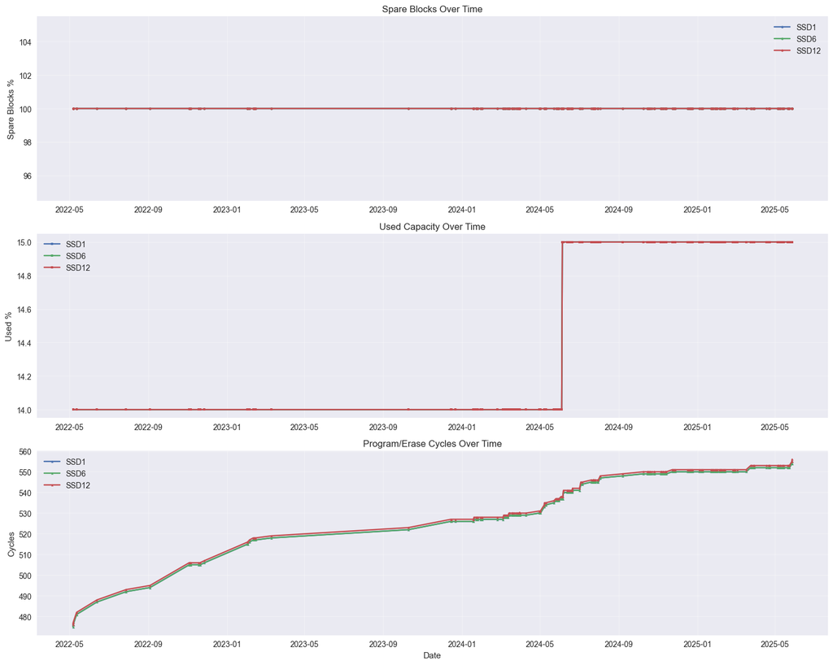

```python
# Individual SSD trends over time
fig, axes = plt.subplots(3, 1, figsize=(15, 12))

# Select a few representative SSDs
sample_ssds = ['SSD1', 'SSD6', 'SSD12']  # Young, middle, older based on power-on hours

for ssd in sample_ssds:
    ssd_timeline = ssd_df[ssd_df['ssd_name'] == ssd].sort_values('timestamp')

    # Plot key metrics over time
    axes[0].plot(ssd_timeline['timestamp'], ssd_timeline['sm_spare'],
                 label=ssd, marker='o', markersize=3)
    axes[1].plot(ssd_timeline['timestamp'], ssd_timeline['sm_used'],
                 label=ssd, marker='s', markersize=3)
    axes[2].plot(ssd_timeline['timestamp'], ssd_timeline['sm_pc'],
                 label=ssd, marker='^', markersize=3)

axes[0].set_title('Spare Blocks Over Time')
axes[0].set_ylabel('Spare Blocks %')
axes[0].legend()
axes[0].grid(True, alpha=0.3)

axes[1].set_title('Used Capacity Over Time')
axes[1].set_ylabel('Used %')
axes[1].legend()
axes[1].grid(True, alpha=0.3)

axes[2].set_title('Program/Erase Cycles Over Time')
axes[2].set_ylabel('Cycles')
axes[2].set_xlabel('Date')
axes[2].legend()
axes[2].grid(True, alpha=0.3)

plt.tight_layout()
plt.show()
```

```python
# Project when SSDs might hit concerning thresholds
# Fit trend line to recent cycle data
recent_data = ssd_df[ssd_df['timestamp'] >= '2024-01-01']
recent_cycles = recent_data.groupby('timestamp')['sm_pc'].mean()

# Linear regression on recent trend
x = np.arange(len(recent_cycles))
y = recent_cycles.values
slope, intercept = np.polyfit(x, y, 1)

print(f"Current wear rate: {slope:.2f} cycles per data point")
print(f"Projected cycles in 6 months: {recent_cycles.iloc[-1] + (slope * 50):.0f}")
```

```
Current wear rate: 0.09 cycles per data point
Projected cycles in 6 months: 561
```

#### Implements a basic predictive maintenance analytics using linear trend analysis. I decided to focus on 2024+ to ensure it is based on current operational patterns. I decided to go with linear regression here as it provides a simple and effective baseline for wear projection. I have found that the program/erase cycles are the primary wear indicators for flash memory.

#### The minimal wear progression correlates with my initial thought that this is a under utilized or a testing device.

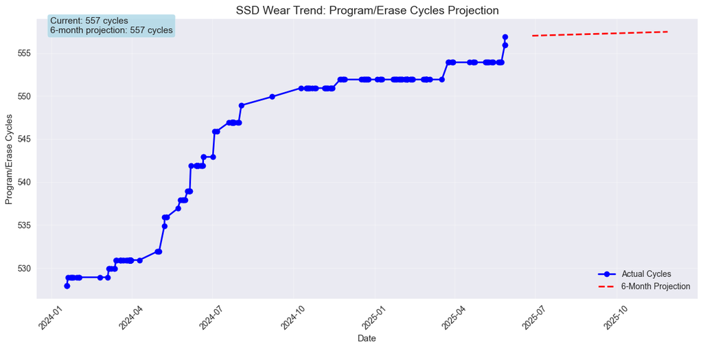

```
Current cycles: 557
Wear rate: 0.091 cycles per period
6-month projection: 557 cycles
```

```python
# Simple trend projection
recent_data = ssd_df[ssd_df['timestamp'] >= '2024-01-01']
recent_cycles = recent_data.groupby('timestamp')['sm_pc'].mean()

# Fit trend line
x = np.arange(len(recent_cycles))
y = recent_cycles.values
slope, intercept = np.polyfit(x, y, 1)

# Create simple projection
fig, ax = plt.subplots(1, 1, figsize=(12, 6))

# Plot actual data
ax.plot(recent_cycles.index, recent_cycles.values, 'o-',
        color='blue', linewidth=2, label='Actual Cycles')

# Project 6 months ahead
last_date = recent_cycles.index[-1]
future_dates = [last_date + pd.DateOffset(months=i) for i in range(1, 7)]
current_cycles = recent_cycles.iloc[-1]
future_cycles = [current_cycles + (slope * i) for i in range(1, 7)]

# Plot projection
ax.plot(future_dates, future_cycles, '--',
        color='red', linewidth=2, label='6-Month Projection')

# Add current and projected values as text
ax.text(0.02, 0.95, f'Current: {current_cycles:.0f} cycles\n6-month projection: {future_cycles[-1]:.0f} cycles',
        transform=ax.transAxes, fontsize=11,
        bbox=dict(boxstyle='round', facecolor='lightblue', alpha=0.8))

ax.set_title('SSD Wear Trend: Program/Erase Cycles Projection', fontsize=14)
ax.set_xlabel('Date')
ax.set_ylabel('Program/Erase Cycles')
ax.legend()
ax.grid(True, alpha=0.3)

plt.xticks(rotation=45)
plt.tight_layout()
plt.show()

print(f"Current cycles: {current_cycles:.0f}")
print(f"Wear rate: {slope:.3f} cycles per period")
print(f"6-month projection: {future_cycles[-1]:.0f} cycles")
```

## Here im looking at the NS_DF to see workload info.

```python
# Basic namespace insights
print("=== NAMESPACE WORKLOAD ANALYSIS ===")
print(f"Total namespaces: {ns_df['namespace_name'].nunique()}")
print(f"Namespace records: {len(ns_df)}")
print(f"Time range: {ns_df['timestamp'].min()} to {ns_df['timestamp'].max()}")

# Top workload stressors
workload_summary = ns_df.groupby('namespace_name').agg({
    'read_ops': 'sum',
    'write_ops': 'sum',
    'read_bytes': 'sum',
    'write_bytes': 'sum',
    'read_misalign': 'sum',
    'write_misalign': 'sum'
})

# Calculate stress indicators
workload_summary['total_ops'] = workload_summary['read_ops'] + workload_summary['write_ops']
workload_summary['write_misalign_rate'] = workload_summary['write_misalign'] / workload_summary['write_ops']
workload_summary['read_misalign_rate'] = workload_summary['read_misalign'] / workload_summary['read_ops']

print("\nTop 5 Most Active Namespaces:")
print(workload_summary.nlargest(5, 'total_ops')[['total_ops', 'write_misalign_rate']])

print("\nTop 5 Highest Misalignment (SSD Stress):")
print(workload_summary.nlargest(5, 'write_misalign_rate')[['total_ops', 'write_misalign_rate']])
```

```
=== NAMESPACE WORKLOAD ANALYSIS ===
Total namespaces: 21
Namespace records: 790
Time range: 2022-04-15 19:35:32.387000+00:00 to 2025-05-27 21:52:37.772000+00:00

Top 5 Most Active Namespaces:
                          total_ops  write_misalign_rate
namespace_name
DWW Mac Backup         4.768091e+10         16489.439636
Time Machine           2.479295e+10         25570.742064
JJWW Time Machine      1.594482e+09         26043.977044
Photo & Video Archive  1.266520e+09          9022.819243
Windows PD Test        3.933212e+08           533.077805

Top 5 Highest Misalignment (SSD Stress):
                   total_ops  write_misalign_rate
namespace_name
Windows              18838.0         31590.151858
Windows Test        239588.0         30993.960036
Virtual Machines  62067073.0         30423.333753
Hedge Test 2       1041949.0         29499.169906
iPad Test             2897.0         29053.733458
```

```python
# Identify application types by I/O patterns
def classify_workload_type(row):
    read_write_ratio = row['read_ops'] / max(row['write_ops'], 1)
    misalign_rate = row['write_misalign_rate']

    if read_write_ratio > 10:
        return "Read-Heavy (Archive/Backup)"
    elif read_write_ratio < 0.5:
        return "Write-Heavy (Database/Logs)"
    elif misalign_rate > 1000:
        return "High-Stress (Time Machine/Sync)"
    else:
        return "Balanced (General Use)"

workload_summary['workload_type'] = workload_summary.apply(classify_workload_type, axis=1)

print("\nWorkload Classification:")
print(workload_summary['workload_type'].value_counts())

# Show examples of each type
for workload_type in workload_summary['workload_type'].unique():
    examples = workload_summary[workload_summary['workload_type'] == workload_type].head(2)
    print(f"\n{workload_type} Examples:")
    print(examples[['total_ops', 'write_misalign_rate']].round(2))
```

```
Workload Classification:
workload_type
High-Stress (Time Machine/Sync)    17
Balanced (General Use)              2
Write-Heavy (Database/Logs)         1
Read-Heavy (Archive/Backup)         1
Name: count, dtype: int64

High-Stress (Time Machine/Sync) Examples:
                   total_ops  write_misalign_rate
namespace_name
DWW Mac Backup  4.768091e+10             16489.44
Danes Test      9.583152e+06             28772.78

Write-Heavy (Database/Logs) Examples:
                 total_ops  write_misalign_rate
namespace_name
Photos          12438391.0             28701.08

Balanced (General Use) Examples:
                   total_ops  write_misalign_rate
namespace_name
Windows PD Test  393321188.0               533.08
raw                 614630.0                 0.00

Read-Heavy (Archive/Backup) Examples:
                total_ops  write_misalign_rate
namespace_name
foo1                 82.0                  NaN
```

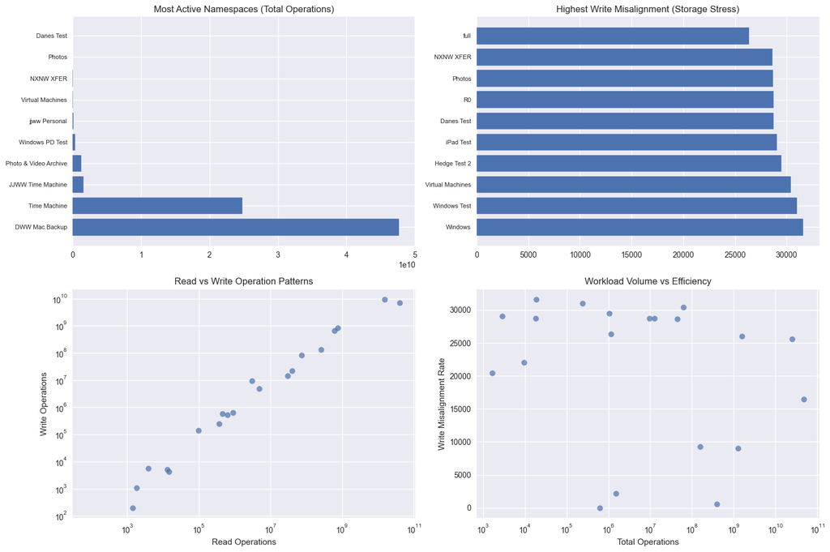

```python
# Graph namespace impact on storage
fig, axes = plt.subplots(2, 2, figsize=(15, 10))

# 1. Operations volume by namespace(Heaviest workload contributors)
top_namespaces = workload_summary.nlargest(10, 'total_ops')
axes[0,0].barh(range(len(top_namespaces)), top_namespaces['total_ops'])
axes[0,0].set_title('Most Active Namespaces (Total Operations)')
axes[0,0].set_yticks(range(len(top_namespaces)))
axes[0,0].set_yticklabels(top_namespaces.index, fontsize=8)

# 2. Misalignment stress patterns(Storage efficiency)
top_stress = workload_summary.nlargest(10, 'write_misalign_rate')
axes[0,1].barh(range(len(top_stress)), top_stress['write_misalign_rate'])
axes[0,1].set_title('Highest Write Misalignment (Storage Stress)')
axes[0,1].set_yticks(range(len(top_stress)))
axes[0,1].set_yticklabels(top_stress.index, fontsize=8)

# 3. Read vs Write patterns
axes[1,0].scatter(workload_summary['read_ops'], workload_summary['write_ops'], alpha=0.7)
axes[1,0].set_title('Read vs Write Operation Patterns')
axes[1,0].set_xlabel('Read Operations')
axes[1,0].set_ylabel('Write Operations')
axes[1,0].set_xscale('log')
axes[1,0].set_yscale('log')

# # 4. Workload efficiency( Im not sure what to think this. Looks like nor correlation between these two)
axes[1,1].scatter(workload_summary['total_ops'], workload_summary['write_misalign_rate'], alpha=0.7)
axes[1,1].set_title('Workload Volume vs Efficiency')
axes[1,1].set_xlabel('Total Operations')
axes[1,1].set_ylabel('Write Misalignment Rate')
axes[1,1].set_xscale('log')

plt.tight_layout()
plt.show()
```

```python
# Let's see if high-stress workloads correlate with SSD faults
# Time-based correlation
high_stress_namespaces = workload_summary[
    workload_summary['workload_type'] == 'High-Stress (Time Machine/Sync)'
].index.tolist()
```

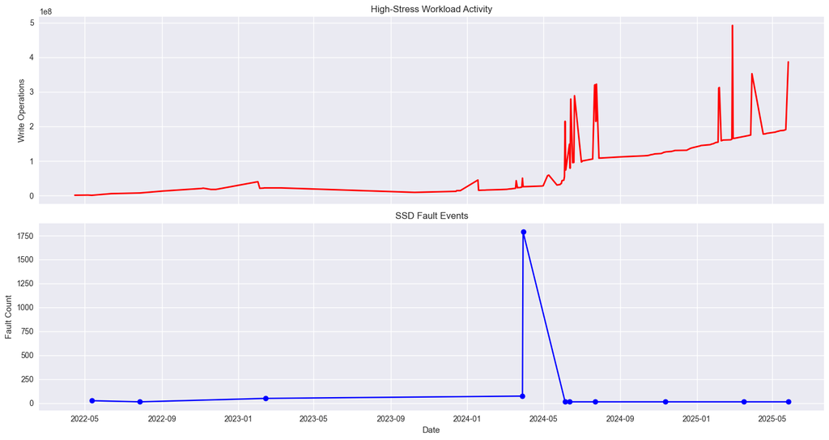

```python
fig, (ax1, ax2) = plt.subplots(2, 1, figsize=(15, 8), sharex=True)

# Plot high-stress workload activity over time
stress_daily = ns_df[ns_df['namespace_name'].isin(high_stress_namespaces)].groupby(
    ns_df['timestamp'].dt.date
)['write_ops'].sum()

ax1.plot(stress_daily.index, stress_daily.values, color='red', linewidth=2)
ax1.set_title('High-Stress Workload Activity')
ax1.set_ylabel('Write Operations')

# Plot fault events over time
fault_daily = ssd_df[ssd_df['log_type'] == 'FAULT'].groupby(
    ssd_df['timestamp'].dt.date
).size()

ax2.plot(fault_daily.index, fault_daily.values, color='blue', marker='o')
ax2.set_title('SSD Fault Events')
ax2.set_ylabel('Fault Count')
ax2.set_xlabel('Date')

plt.tight_layout()
plt.show()
```

#### Here i wanted to look at the temporal correlation between high-stress workload patterns and fault occcurences on the same time scale to possibly identify root causes. This would help determine if intensive operations trigger system failures. I was expecting to see a positive correlation between high workload and fault events. What we see is completely different. My assumption is that this being a under utilized device and then going to high use, indicates that the system might me resilient enough to adapt to the higher stress workloads.